# Red Wine Analysis and Exploration by Mustafa Abaas

# Description

This project is aiming to exploring, analyzing and drawing conclusion out of a tidy data set about Red Wine quality provided by Udacity.

> **Guidance**: Throughout the project and before every section, a header shall be included clarifying the purpose of that section.

# Preliminary Exploration

> **Flash Forward**: In this section there will be some preliminary exploration of the dataset, Including running some summaries of the data and create univariate plots to understand the structure of the individual variables in the dataset.

## The data set structure

```
##  [1] "X"                    "fixed.acidity"        "volatile.acidity"
##  [4] "citric.acid"          "residual.sugar"       "chlorides"
##  [7] "free.sulfur.dioxide"  "total.sulfur.dioxide" "density"
## [10] "pH"                   "sulphates"            "alcohol"
## [13] "quality"
```

```
## 'data.frame':    1599 obs. of  13 variables:
##  $ X                   : int  1 2 3 4 5 6 7 8 9 10 ...
##  $ fixed.acidity       : num  7.4 7.8 7.8 11.2 7.4 7.4 7.9 7.3 7.8 7.5 ...
##  $ volatile.acidity    : num  0.7 0.88 0.76 0.28 0.7 0.66 0.6 0.65 0.58 0.5 ...
##  $ citric.acid         : num  0 0 0.04 0.56 0 0 0.06 0 0.02 0.36 ...
##  $ residual.sugar      : num  1.9 2.6 2.3 1.9 1.9 1.8 1.6 1.2 2 6.1 ...
##  $ chlorides           : num  0.076 0.098 0.092 0.075 0.076 0.075 0.069 0.065 0.073 0.071 ...
##  $ free.sulfur.dioxide : num  11 25 15 17 11 13 15 15 9 17 ...
##  $ total.sulfur.dioxide: num  34 67 54 60 34 40 59 21 18 102 ...
##  $ density             : num  0.998 0.997 0.997 0.998 0.998 ...
##  $ pH                  : num  3.51 3.2 3.26 3.16 3.51 3.51 3.3 3.39 3.36 3.35 ...
##  $ sulphates           : num  0.56 0.68 0.65 0.58 0.56 0.56 0.46 0.47 0.57 0.8 ...
##  $ alcohol             : num  9.4 9.8 9.8 9.8 9.4 9.4 9.4 10 9.5 10.5 ...
##  $ quality             : int  5 5 5 6 5 5 5 7 7 5 ...
```

### Observations:

The data set contains:

- About 1600 observations.
- 12 variables in addition to a unique identifier.
- The data types are all numeric except for the quality.

## Statistical Flash Forward of the data set

```
##        X          fixed.acidity   volatile.acidity  citric.acid
##  Min.   :   1.0   Min.   : 4.60   Min.   :0.1200   Min.   :0.000
##  1st Qu.: 400.5   1st Qu.: 7.10   1st Qu.:0.3900   1st Qu.:0.090
##  Median : 800.0   Median : 7.90   Median :0.5200   Median :0.260
##  Mean   : 800.0   Mean   : 8.32   Mean   :0.5278   Mean   :0.271
##  3rd Qu.:1199.5   3rd Qu.: 9.20   3rd Qu.:0.6400   3rd Qu.:0.420
##  Max.   :1599.0   Max.   :15.90   Max.   :1.5800   Max.   :1.000
##  residual.sugar     chlorides       free.sulfur.dioxide
##  Min.   : 0.900   Min.   :0.01200   Min.   : 1.00
##  1st Qu.: 1.900   1st Qu.:0.07000   1st Qu.: 7.00
##  Median : 2.200   Median :0.07900   Median :14.00
##  Mean   : 2.539   Mean   :0.08747   Mean   :15.87
##  3rd Qu.: 2.600   3rd Qu.:0.09000   3rd Qu.:21.00
##  Max.   :15.500   Max.   :0.61100   Max.   :72.00
##  total.sulfur.dioxide    density             pH          sulphates
##  Min.   :  6.00       Min.   :0.9901   Min.   :2.740   Min.   :0.3300
##  1st Qu.: 22.00       1st Qu.:0.9956   1st Qu.:3.210   1st Qu.:0.5500
##  Median : 38.00       Median :0.9968   Median :3.310   Median :0.6200
##  Mean   : 46.47       Mean   :0.9967   Mean   :3.311   Mean   :0.6581
##  3rd Qu.: 62.00       3rd Qu.:0.9978   3rd Qu.:3.400   3rd Qu.:0.7300
##  Max.   :289.00       Max.   :1.0037   Max.   :4.010   Max.   :2.0000
##     alcohol         quality
##  Min.   : 8.40   Min.   :3.000
##  1st Qu.: 9.50   1st Qu.:5.000
##  Median :10.20   Median :6.000
##  Mean   :10.42   Mean   :5.636
##  3rd Qu.:11.10   3rd Qu.:6.000
##  Max.   :14.90   Max.   :8.000
```

## Univariate Plots Section

In this part we are just building an intuition for the data we are dealing with here.

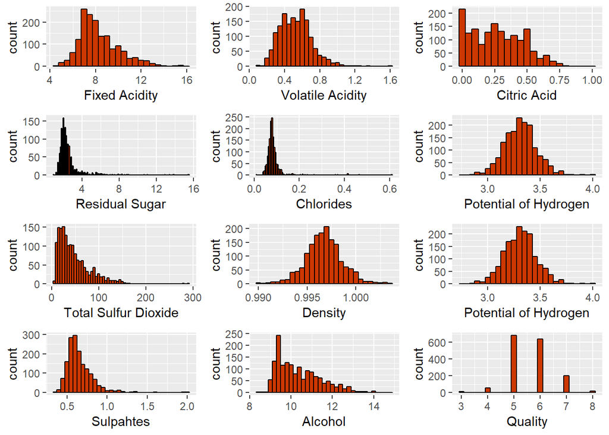

Observations:

- Most of variables have a normally distributed shape.
- Residual sugar and chlorides variables have cleaar evidence to the existance of outliers! The data is over crowded on the lower values, maybe there we can find some sort of a pattern.

## Zooming in on some of the interesting variables

> **Wine Quality Distribution**:

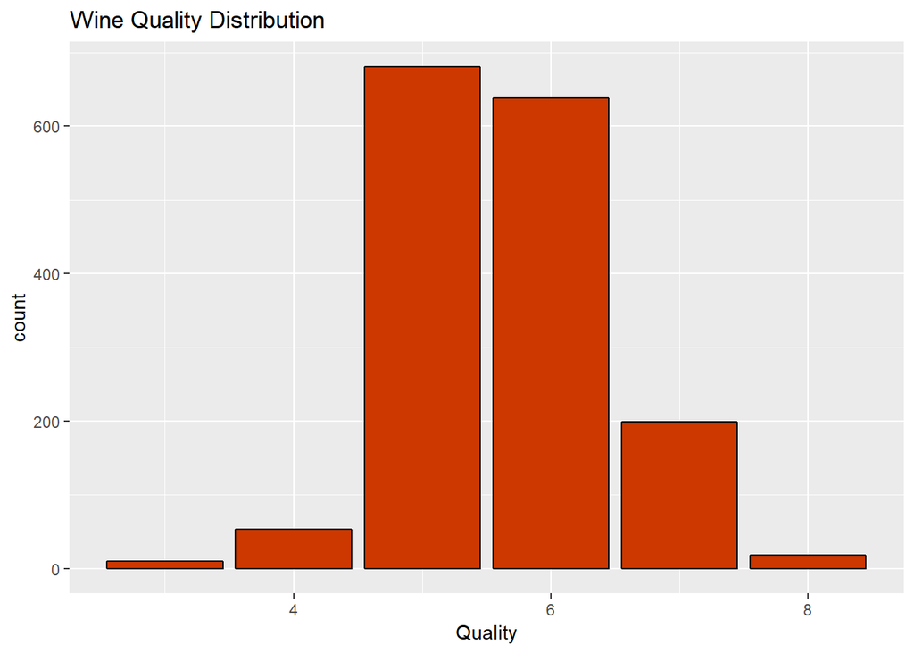

```
##    Min. 1st Qu.  Median    Mean 3rd Qu.    Max.
##   3.000   5.000   6.000   5.636   6.000   8.000
```

### Observations:

- The quality follows a normal distribution with a mean value of nearly 5.6.

> **Alcohol Content Distribution**:

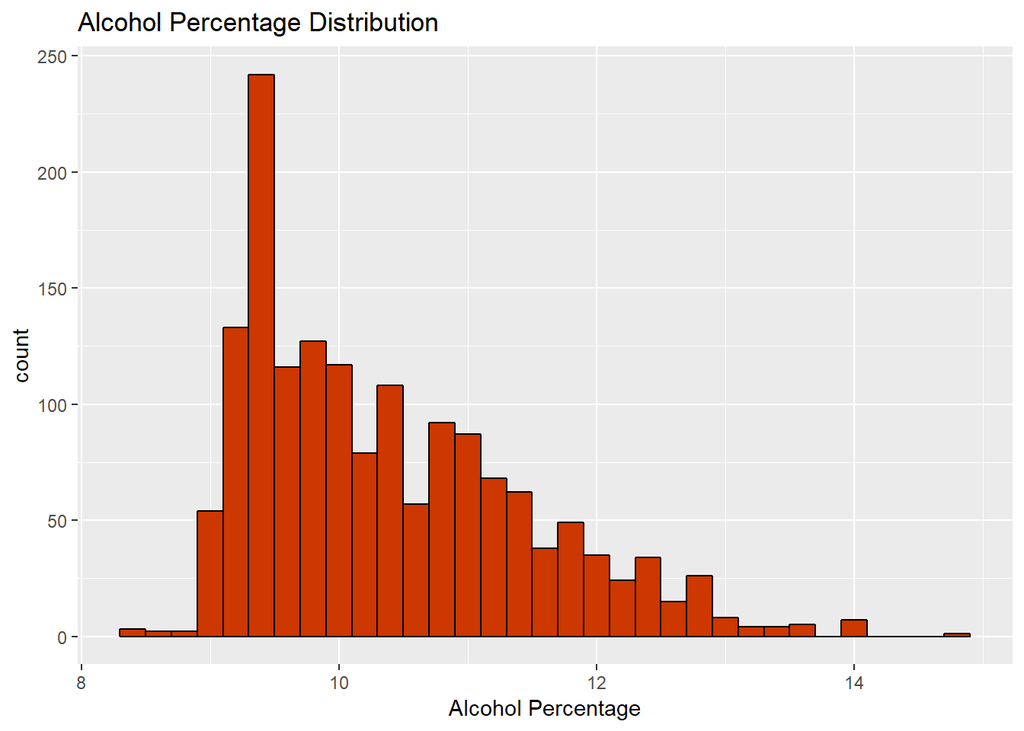

```
##    Min. 1st Qu.  Median    Mean 3rd Qu.    Max.
##    8.40    9.50   10.20   10.42   11.10   14.90
```

> **Residual Sugar Distribution**:

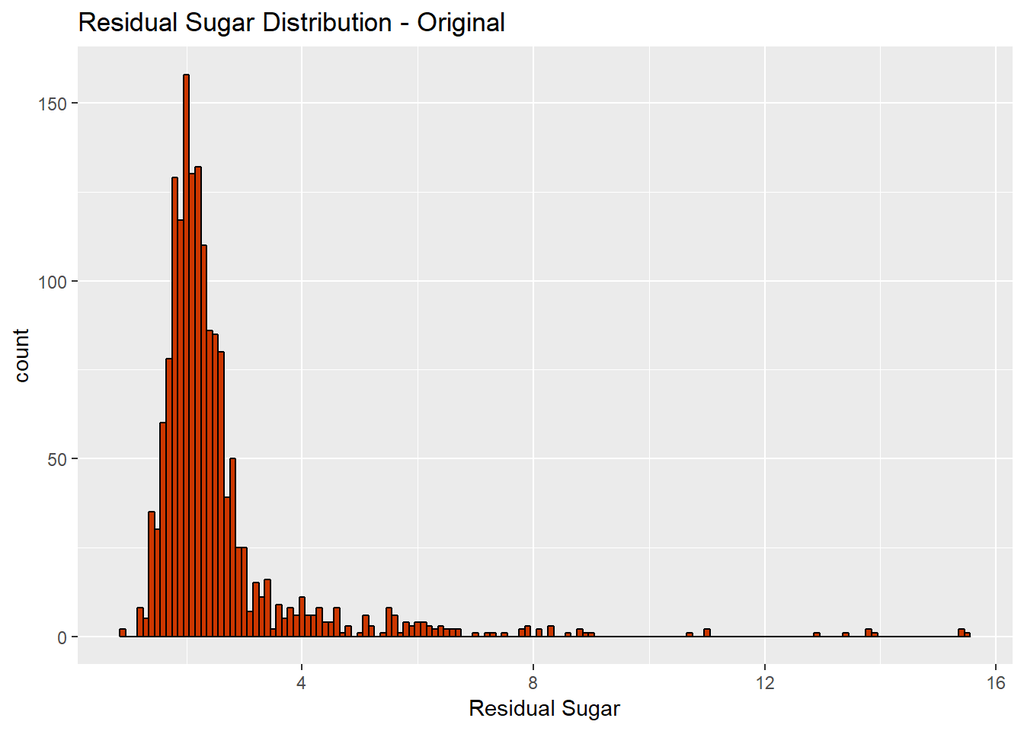

There is outliers in this specific variable, we might try omitting them (those samples that have residual sugar greater than 5) for a more fair conclusion.

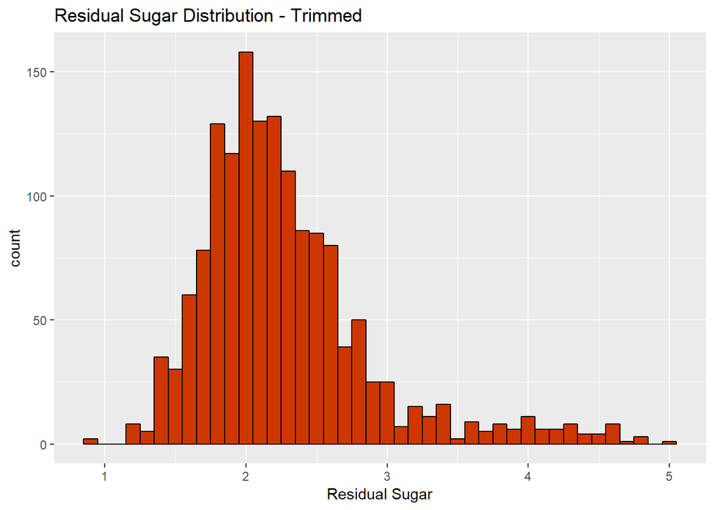

Summary statistics for the trimmed data:

```
##    Min. 1st Qu.  Median    Mean 3rd Qu.    Max.
##   0.900   1.900   2.200   2.274   2.500   5.000
```

Back to our data set, we notice that:

```
##    Min. 1st Qu.  Median    Mean 3rd Qu.    Max.
##   0.900   1.900   2.200   2.539   2.600  15.500
```

### Observations:

- It’s almost a right sekwed distribution if we took even the outliers into consideration, and it’s a normal distribution otherwise.
- The interesting thing to notice is that, there is a spike in this graph indicating that most red wine types are not very sweet with a low sugar level, does that has something to do with quality? In other words Do red wine types with less sugar content have the best quality? This is what the Bivariate section will handle.

## Total acidity Distribution

Instead of dealing with each variable one at a time, i had an idea of observing the overall acidity levels in a given sample! Hopefully a pattern shall be revealed later on.

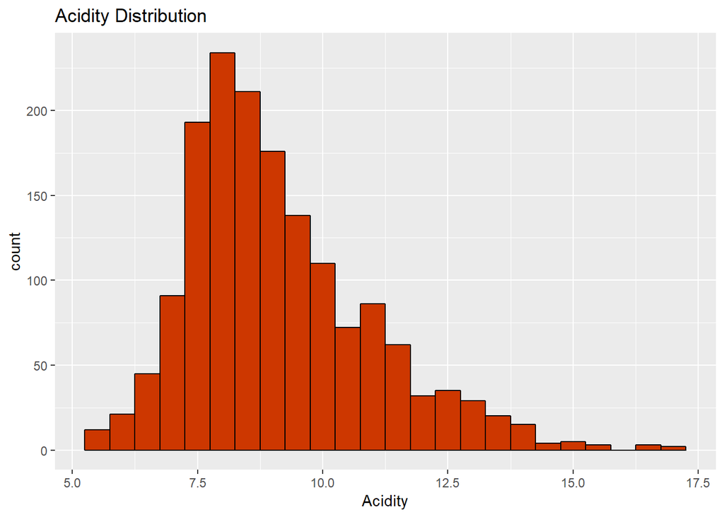

```
##    Min. 1st Qu.  Median    Mean 3rd Qu.    Max.
##   5.270   7.827   8.720   9.118  10.070  17.045
```

### Observations:

# Univariate Analysis

> **Flash Forward**: In this section, there are two main objectives. The first one is to simply answer some of the recommended questions (‘Some’ because the rest were already answered above or will be answered in the second objective of this section), and the second one is to modify the dataset for later usage, mainly converting quantitive variables into categorical ones.

### What is the structure of your dataset?

- About 1600 observations.
- 12 variables in addition to a unique identifier.
- The data types are all numeric except for the quality.

### What is/are the main feature(s) of interest in your dataset?

I think the answer to this question, is with no doubt **Quality** as it’s the most important factor in any commercial process. I only wish a coloumn for the price was in presense, that would be very interesting to look at.

In this project i’ll pay the most attention to the **Acidity** (A coloumn i created, refer to the previous section for more details), and to the **Residual sugar** coloumn.

Note that: Additional coloumns might be used.

## Second objective : Modifying The Residual Sugar Variable

```
##    Min. 1st Qu.  Median    Mean 3rd Qu.    Max.
##   0.900   1.900   2.200   2.539   2.600  15.500
```

### Modifying technique

Let’s create a new coloumn that represents the sugar amount in the wine, calissifying each observation into low, moderate and high by following the next pattern:

- Low : 0.9 - 1.9
- Moderate : 1.9 - 2.6
- High : 2.6 - 15.5

### Plotting

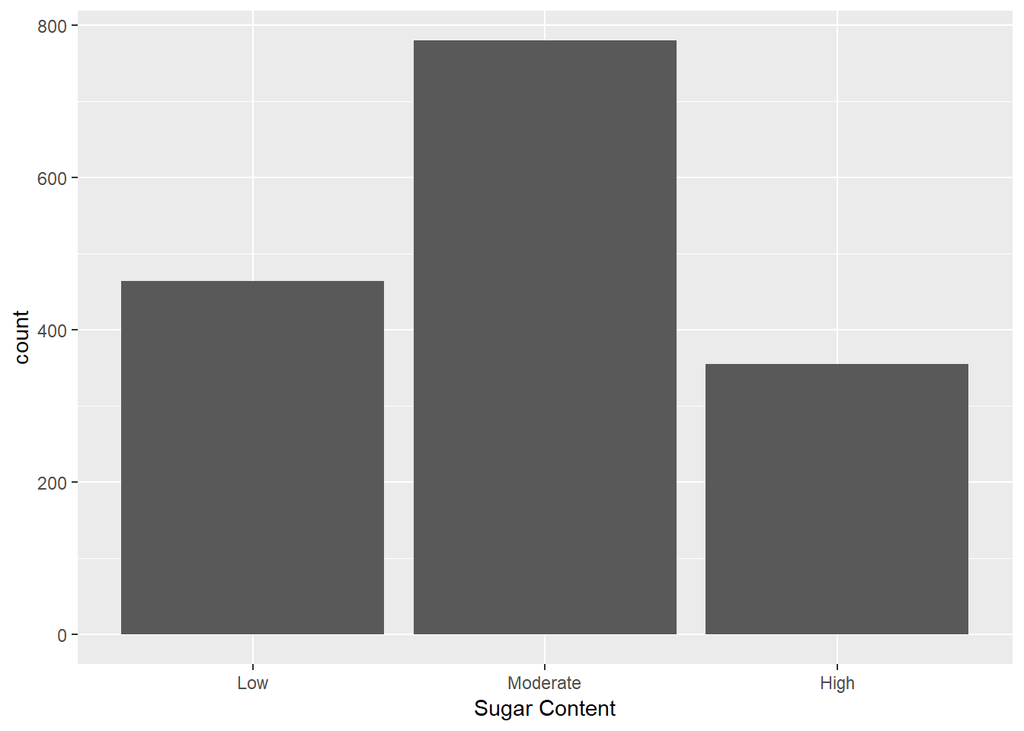

```
##    Min. 1st Qu.  Median    Mean 3rd Qu.    Max.
##   3.000   5.000   6.000   5.636   6.000   8.000
```

### Modifying technique

Again, let’s create a new coloumn that represents the quality, calissifying each observation into poor, good and excellent by following the next pattern:

- Poor : 3 - 5
- Good : 5 - 6
- Excellent : 6 - 8

### Plotting

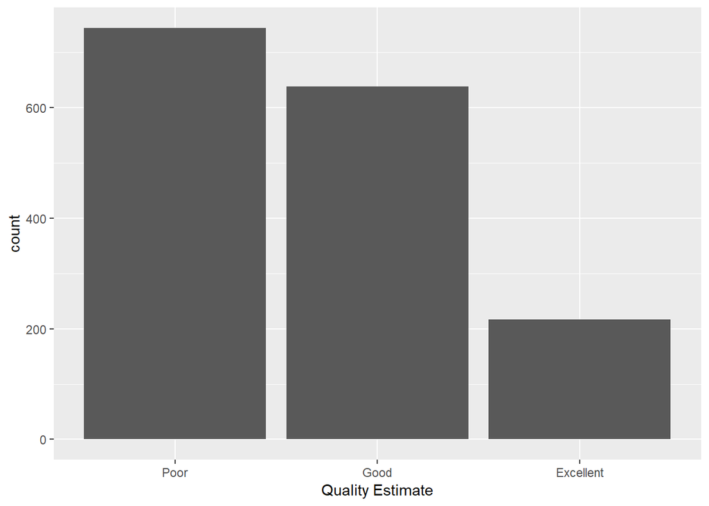

# Bivariate Plots Section

> **Flash Forward**: In this section, we will buil plots based on what we saw in the univariate plots and what relationships between variables might be interesting to look at. We will look at relationships between supporting variables as well.

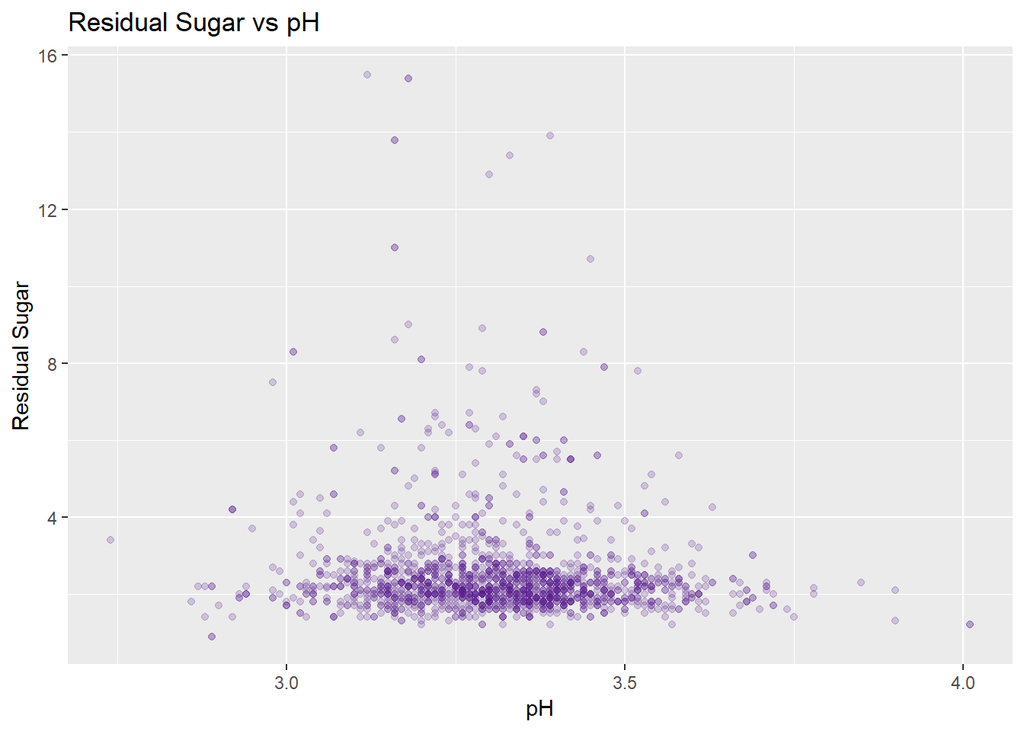

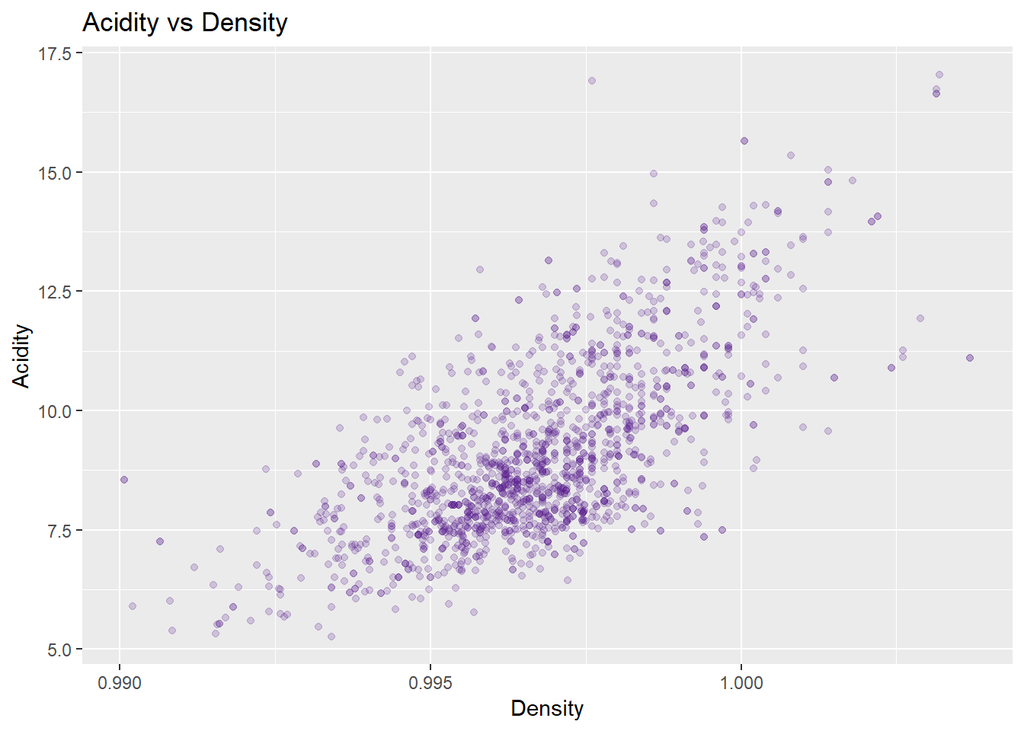

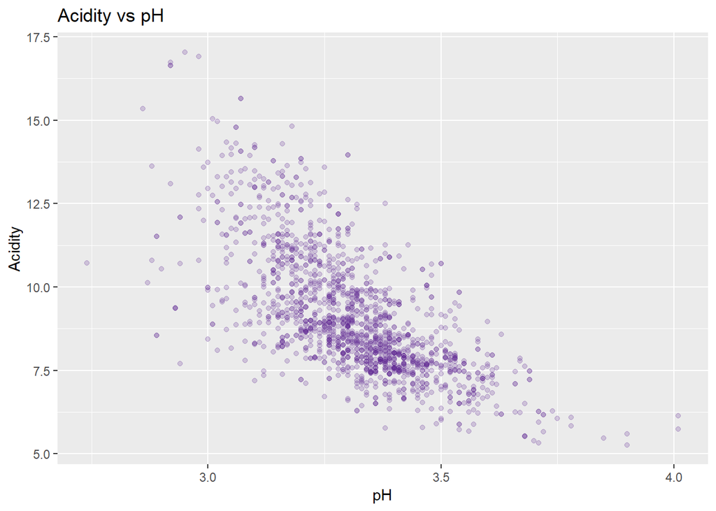

# Bivariate Analysis

> **Flash Forward**: In this section, I’ll just answer the recommended questions.

### Talk about some of the relationships you observed in this part of the investigation. How did the feature(s) of interest vary with other features in the dataset?

As mentioned before i decided to create a new coloumn that represents the overall **acidity** in the dataset, it turns out the the total **acidity** has strong correlation with denisity. Also the **pH** is strongly negatively correlated with the total **acidity**.

### Did you observe any interesting relationships between the other features (not the main feature(s) of interest)?

Yes, for example, the relation between **residual sugar** and **pH** is quite strange. Because as pH increases, the residual sugar is maintaing a certain range of values despite some outliers i pointed out earlier.

### What was the strongest relationship you found?

The **acidity** vs **density**! they are strongly positively correlated.

# Multivariate Plots Section

> **Flash Forward**: In this section, we will build plots based on what we saw in the bivariate plots and what relationships between variables might be interesting to look at, in this secion each plot has *Cause* which explains why i chose to notice the relation between these variables.

## To be investagated: Relationship between pH and alcohol in terms of quality and sugar content.

> **Cause:** Since we want to observe the relation between sugar content and other variables in terms of quality.

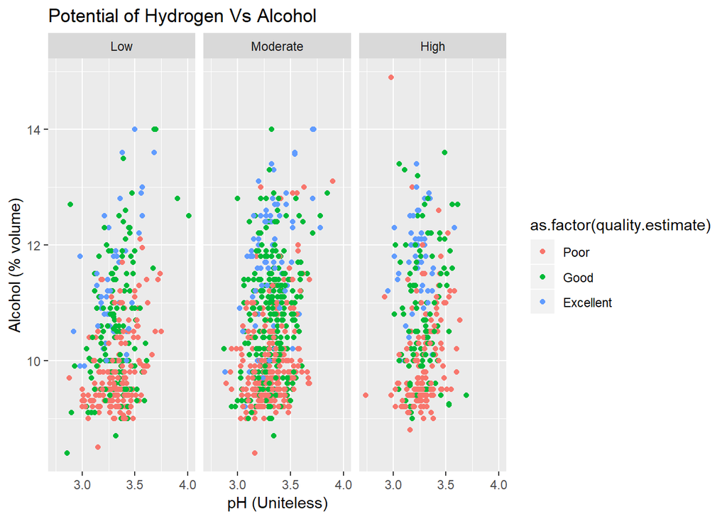

## To be investagated: Relationship between density and alcohol in terms of quality.

> **Cause:** Since both showed a clear bias when being plotted.

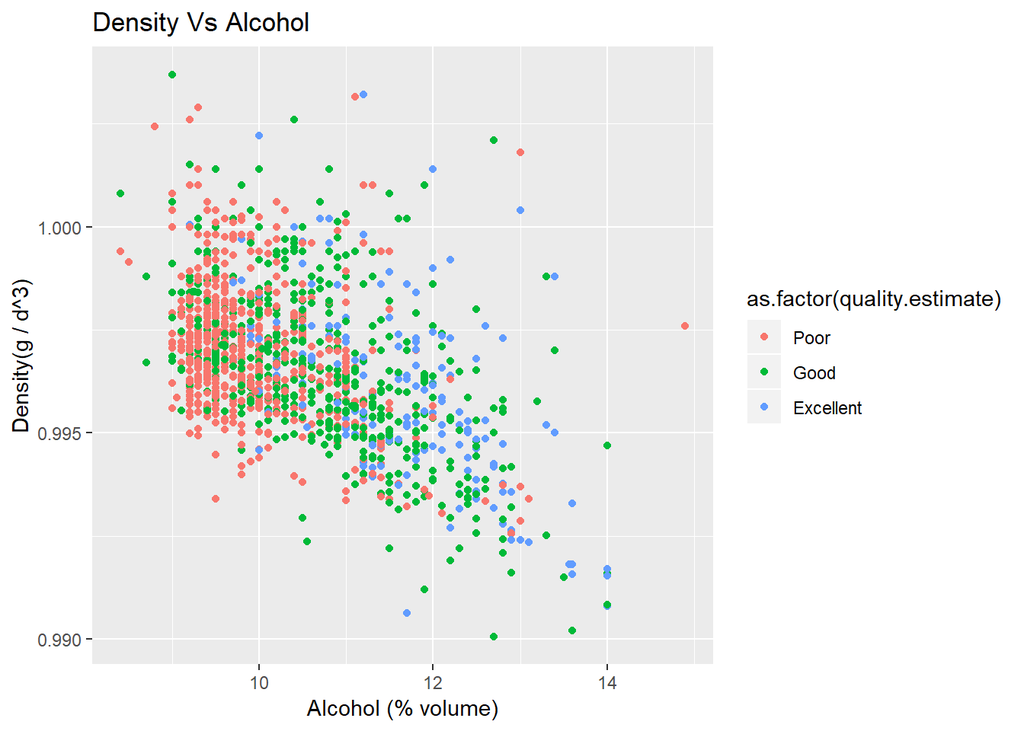

## To be investagated: Relationship Density and acidity in terms of quality.

> **Cause:** Because they seem to have the same distribution shape and according to the bivirate plot on the previous section, they are strongly possitively correlated, so there is a reasonable chance to find correlation between them and the quality of the samples.

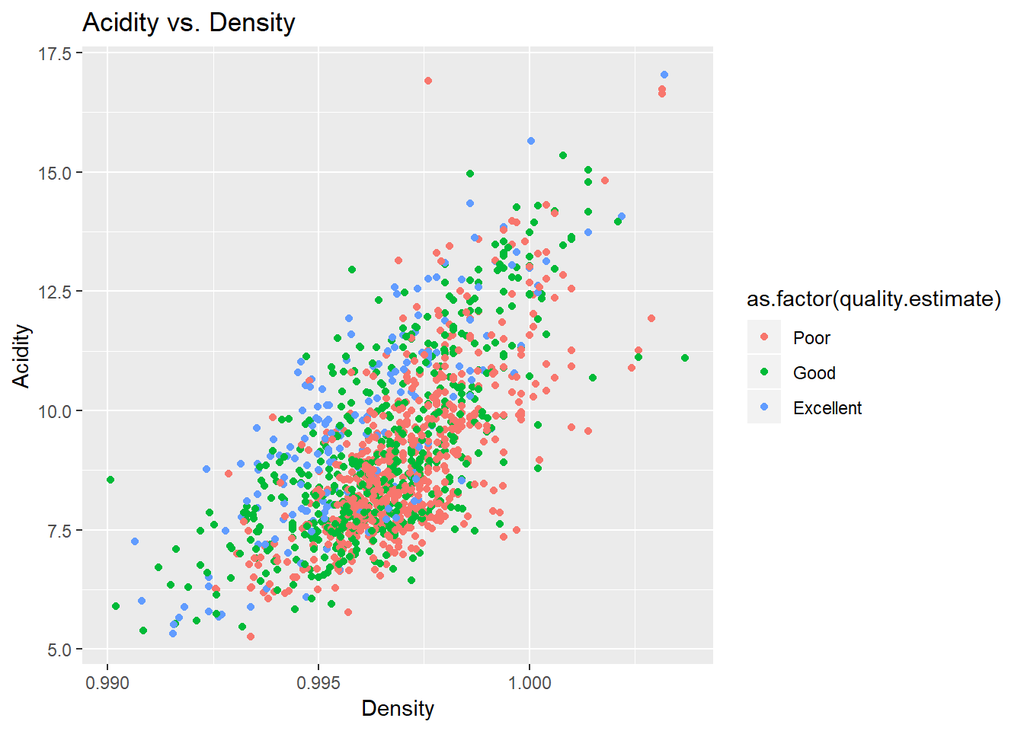

# Multivariate Analysis

> **Flash Forward**: In this section, I’ll just answer the recommended questions.

### Talk about some of the relationships you observed in this part of the investigation. Were there features that strengthened each other in terms of looking at your feature(s) of interest?

# Final Plots and Summary

### Plot One

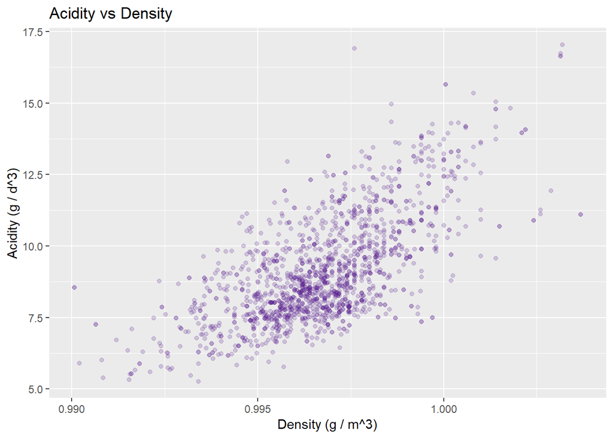

### Description One

The acidity and density are strongly positively correlated! This might tell a lot about our dataset.

### Plot Two

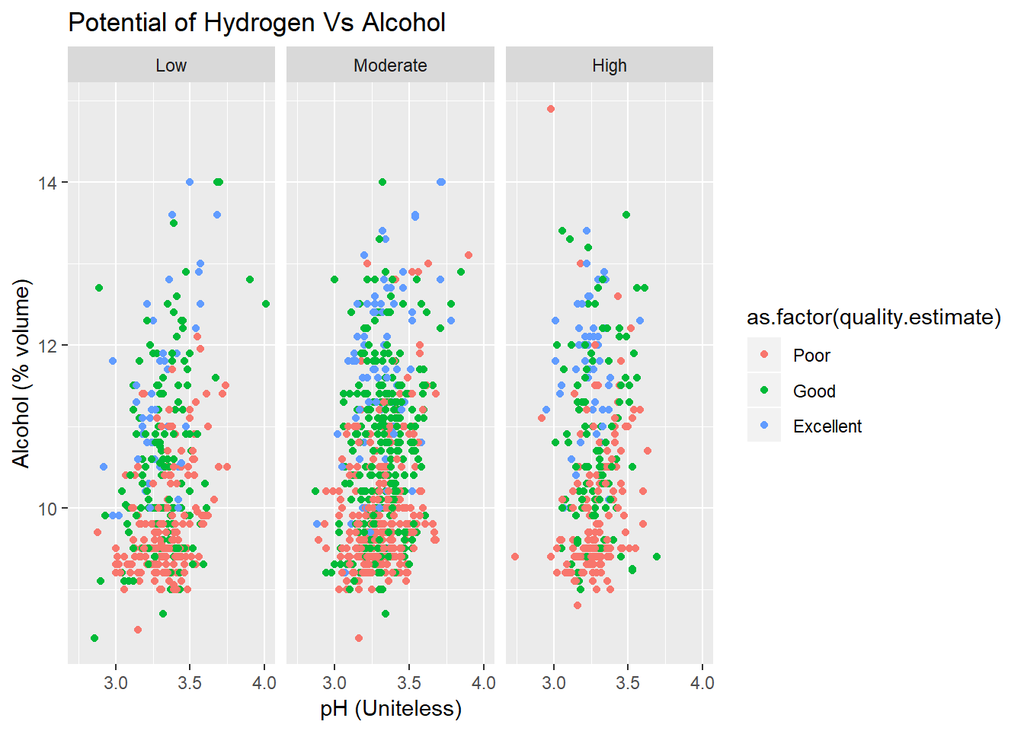

### Plot Three

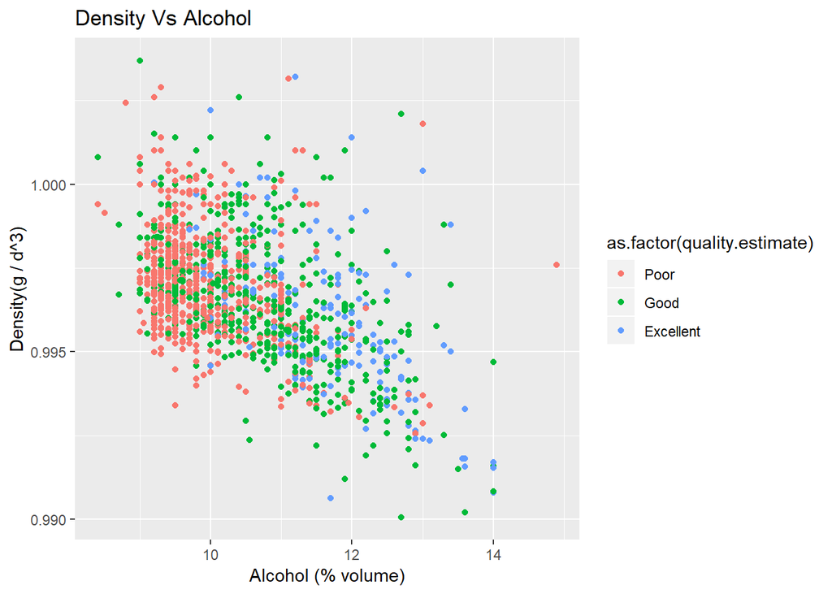

# Reflection

> **Flash Forward**: In this sectio, I’ll mention some of the struggles that i went through? What went well? What was surprising? Also i’ll include an insight into future work that could be done with the dataset.

## Project walk through:

The data set i worked with was pretty small and tidy and it surely was an advantage. The struggle in the project was all about programming in *R*, since it’s my first time to learn and use this language i spent sometime figuring things out. I was surprised by some correlations between some variables i assumed to have none and also by the absence of correlation between others.

## Future investigation

I think that this data set suffers from the lack of the price factor! if the *price/litre* for example was provided, a better investigation and analysis shall be carried out.

# Referneces

- How to choose bin size, [Stackoverflow answer](https://stackoverflow.com/questions/14200027/how-to-adjust-binwidth-in-ggplot2) to determine the binsize.
- Sequential, diverging and qualitative colour scales from colorbrewer.org on the [official documentation](https://ggplot2.tidyverse.org/reference/scale_brewer.html).
- This [Wikipedia page](https://en.wikipedia.org/wiki/pH) about the pH number as a referesher to high school chemistry.
- Specifying Colours in ggplot, using the following [blog](http://sape.inf.usi.ch/quick-reference/ggplot2/colour).